# Linear Regression Dentist Appointment vs Food Sell

Rahma Fairuz Rania

2024-06-29

This project is from DQLab Data Science Course. We want to know the relation between food selling and people go to dentist using Linear Regression. The dataset can be download here [dentist](https://storage.googleapis.com/dqlab-dataset/kunjungan_dokter_gigi_kota_x_dqlab.tsv) and [food selling](https://storage.googleapis.com/dqlab-dataset/tingkat_penjualan_kota_x_dqlab.tsv)

## libraries

```r
library(dplyr) # data manipulation
library(Hmisc) # data analysis lib
```

## Data Import

```r
dt_dental <- read.csv("E:/2025/DQLAB/R/6 Regression/kunjungan_dokter_gigi_kota_x_dqlab.tsv", header = TRUE, sep = "\t")
dt_food_sell <- read.csv("E:/2025/DQLAB/R/6 Regression/tingkat_penjualan_kota_x_dqlab.tsv", header = TRUE, sep = "\t")
```

```r
head(dt_dental)
```

```
##   Bulan Tahun tingkat.kunjungan.ke.dokter.gigi
## 1     1  1996                               37
## 2     2  1996                               32
## 3     3  1996                               56
## 4     4  1996                               43
## 5     5  1996                               52
## 6     6  1996                               70
```

```r
head(dt_food_sell)
```

```
##   No Bulan Tahun penjualan.permen penjualan.sereal penjualan.buah.pisang
## 1  1     1  1996           200661            10324                112146
## 2  2     2  1996           297141            13150                175417
## 3  3     3  1996           235586             5398                104645
## 4  4     4  1996           299498             7609                112283
## 5  5     5  1996           395824             5190                137083
## 6  6     6  1996           247212            14571                198130
```

```r
# combine both data
# by.x and by.y is for unique key in both data frame
dt <- merge(dt_dental, dt_food_sell, by.x = c("Bulan", "Tahun"), by.y = c("Bulan", "Tahun"), sort = FALSE)
str(dt)
```

```
## 'data.frame':    24 obs. of  7 variables:
##  $ Bulan                           : int  1 2 3 4 5 6 7 8 9 10 ...
##  $ Tahun                           : int  1996 1996 1996 1996 1996 1996 1996 1996 1996 1996 ...
##  $ tingkat.kunjungan.ke.dokter.gigi: int  37 32 56 43 52 70 64 88 74 98 ...
##  $ No                              : int  1 2 3 4 5 6 7 8 9 10 ...
##  $ penjualan.permen                : int  200661 297141 235586 299498 395824 247212 273899 184405 141211 292225 ...
##  $ penjualan.sereal                : int  10324 13150 5398 7609 5190 14571 13407 8914 3663 14756 ...
##  $ penjualan.buah.pisang           : int  112146 175417 104645 112283 137083 198130 194685 100091 194972 133166 ...
```

## Data Wrangling and Visualization

```r
summary(dt)
```

```
##      Bulan           Tahun      tingkat.kunjungan.ke.dokter.gigi
##  Min.   : 1.00   Min.   :1996   Min.   : 32.00
##  1st Qu.: 3.75   1st Qu.:1996   1st Qu.: 55.00
##  Median : 6.50   Median :1996   Median : 75.00
##  Mean   : 6.50   Mean   :1996   Mean   : 75.17
##  3rd Qu.: 9.25   3rd Qu.:1997   3rd Qu.: 90.50
##  Max.   :12.00   Max.   :1997   Max.   :132.00
##        No        penjualan.permen penjualan.sereal penjualan.buah.pisang
##  Min.   : 1.00   Min.   :141211   Min.   : 2372    Min.   :100091
##  1st Qu.: 6.75   1st Qu.:256775   1st Qu.: 5143    1st Qu.:112249
##  Median :12.50   Median :298320   Median : 9366    Median :139996
##  Mean   :12.50   Mean   :310964   Mean   : 9282    Mean   :140682
##  3rd Qu.:18.25   3rd Qu.:393837   3rd Qu.:13711    3rd Qu.:157232
##  Max.   :24.00   Max.   :467572   Max.   :16209    Max.   :198130
```

People who consumed candies and bananas higher than who consumed cereal. The maximum doctor appointment is quite high, there are 132 times people going to dentist.

Not everyone will get toothache after consuming candies, bananas, or cereal. Then we should search for the delay effect, the time gap between we eating food and get toothache.

```r
delayed <- data.frame(month = dt$Bulan, year = dt$Tahun,
                      dentist_appointment = dt$tingkat.kunjungan.ke.dokter.gigi,

                      # candy
                      candy_sell = dt$penjualan.permen,
                      # lag, n for monthly
                      candy_sell1 = lag(dt$penjualan.permen),
                      candy_sell2 = lag(dt$penjualan.permen,2),
                      candy_sell3 = lag(dt$penjualan.permen,3),
                      candy_sell4 = lag(dt$penjualan.permen,4),
                      candy_sell5 = lag(dt$penjualan.permen,5),
                      candy_sell6 = lag(dt$penjualan.permen,6),

                      # bananas
                      banana_sell = dt$penjualan.buah.pisang,
                      banana_sell1 = lag(dt$penjualan.buah.pisang),
                      banana_sell2 = lag(dt$penjualan.buah.pisang,2),
                      banana_sell3 = lag(dt$penjualan.buah.pisang,3),
                      banana_sell4 = lag(dt$penjualan.buah.pisang,4),
                      banana_sell5 = lag(dt$penjualan.buah.pisang,5),
                      banana_sell6 = lag(dt$penjualan.buah.pisang,6),

                      # cereal
                      cereal_sell = dt$penjualan.sereal,
                      cereal_sell1 = lag(dt$penjualan.sereal),
                      cereal_sell2 = lag(dt$penjualan.sereal,2),
                      cereal_sell3 = lag(dt$penjualan.sereal,3),
                      cereal_sell4 = lag(dt$penjualan.sereal,4),
                      cereal_sell5 = lag(dt$penjualan.sereal,5),
                      cereal_sell6 = lag(dt$penjualan.sereal,6))
delayed
```

```
##    month year dentist_appointment candy_sell candy_sell1 candy_sell2
## 1      1 1996                  37     200661          NA          NA
## 2      2 1996                  32     297141      200661          NA
## 3      3 1996                  56     235586      297141      200661
## 4      4 1996                  43     299498      235586      297141
## 5      5 1996                  52     395824      299498      235586
## 6      6 1996                  70     247212      395824      299498
## 7      7 1996                  64     273899      247212      395824
## 8      8 1996                  88     184405      273899      247212
## 9      9 1996                  74     141211      184405      273899
## 10    10 1996                  98     292225      141211      184405
## 11    11 1996                  80     227864      292225      141211
## 12    12 1996                  46     259963      227864      292225
## 13     1 1997                  66     433783      259963      227864
## 14     2 1997                  78     343034      433783      259963
```

[output cut: 110 more lines]

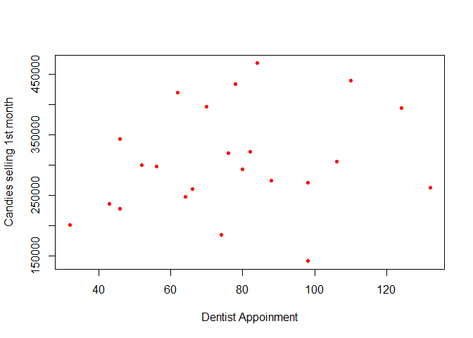

```r
# scatter for relation candy variable
plot(delayed$dentist_appointment, delayed$candy_sell1,
     pch = 20,
     xlab = "Dentist Appoinment",
     ylab = "Candies selling 1st month",
     col = "red")
```

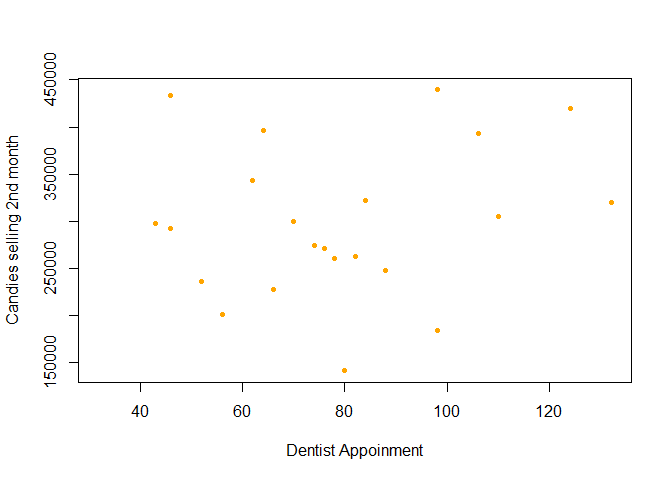

```r
plot(delayed$dentist_appointment, delayed$candy_sell2,
     pch = 20,
     xlab = "Dentist Appoinment",
     ylab = "Candies selling 2nd month",
     col = "orange")
```

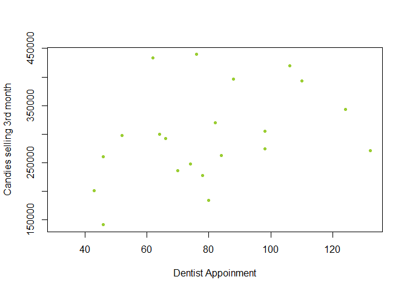

```r
plot(delayed$dentist_appointment, delayed$candy_sell3,
     pch = 20,
     xlab = "Dentist Appoinment",
     ylab = "Candies selling 3rd month",
     col = "yellowgreen")
```

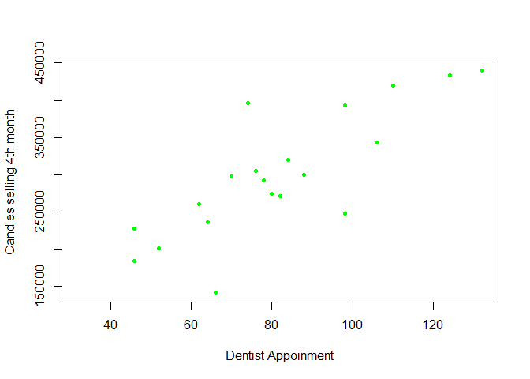

```r
plot(delayed$dentist_appointment, delayed$candy_sell4,
     pch = 20,
     xlab = "Dentist Appoinment",
     ylab = "Candies selling 4th month",
     col = "green")
```

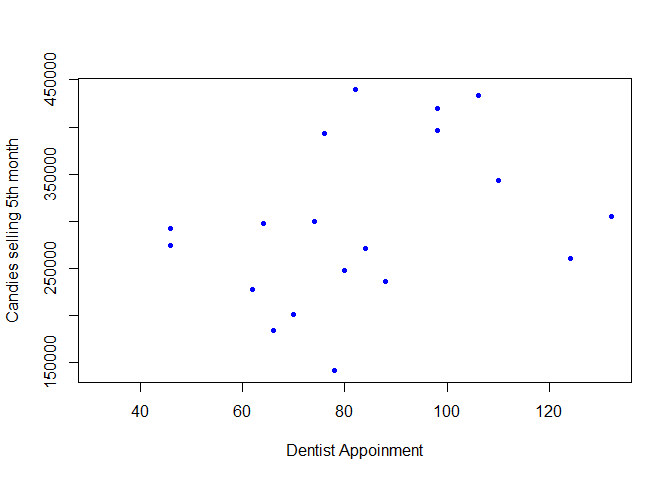

```r
plot(delayed$dentist_appointment, delayed$candy_sell5,
     pch = 20,
     xlab = "Dentist Appoinment",
     ylab = "Candies selling 5th month",
     col = "blue")
```

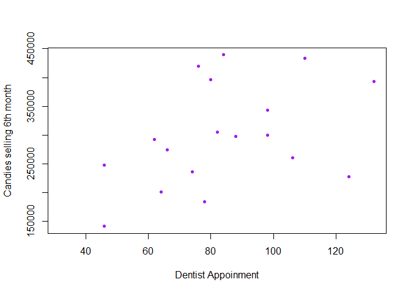

```r
plot(delayed$dentist_appointment, delayed$candy_sell6,
     pch = 20,
     xlab = "Dentist Appoinment",
     ylab = "Candies selling 6th month",
     col = "purple")
```

[figure not shown]

```r
plot(delayed$dentist_appointment, delayed$cereal_sell6,
     pch = 20,
     xlab = "Dentist Appoinment",
     ylab = "Candies selling 6th month",
     col = "gray")
```

[figure not shown]

```r
plot(delayed$dentist_appointment, delayed$banana_sell6,
     pch = 20,
     xlab = "Dentist Appoinment",
     ylab = "Candies selling 6th month",
     col = "steelblue")
```

## Regression Model

```r
# Regression using basic R
month_4th <- data.frame(month = delayed$month,
                  year = delayed$year,
                  dentist_appointment = delayed$dentist_appointment,
                  candies_selling = delayed$candy_sell4,
                  bananas_selling = delayed$banana_sell4,
                  cereal_selling = delayed$cereal_sell4) %>% na.omit()
month_4th
```

```
##    month year dentist_appointment candies_selling bananas_selling
## 5      5 1996                  52          200661          112146
## 6      6 1996                  70          297141          175417
## 7      7 1996                  64          235586          104645
## 8      8 1996                  88          299498          112283
## 9      9 1996                  74          395824          137083
## 10    10 1996                  98          247212          198130
## 11    11 1996                  80          273899          194685
## 12    12 1996                  46          184405          100091
## 13     1 1997                  66          141211          194972
## 14     2 1997                  78          292225          133166
## 15     3 1997                  46          227864          155598
## 16     4 1997                  62          259963          104563
## 17     5 1997                 124          433783          104216
## 18     6 1997                 106          343034          142908
```

[output cut: 27 more lines]

```r
# Regression with linear model
# dentist appointment is our target (dependent variable) and candies_selling is independent variable
mdl_lm <- lm(dentist_appointment ~ candies_selling + bananas_selling + cereal_selling, data = month_4th)
summary(mdl_lm)
```

```
##
## Call:
## lm(formula = dentist_appointment ~ candies_selling + bananas_selling +
##     cereal_selling, data = month_4th)
##
## Residuals:
##     Min      1Q  Median      3Q     Max
## -22.188  -7.019  -2.460   9.383  20.098
##
## Coefficients:
##                   Estimate Std. Error t value Pr(>|t|)
## (Intercept)     -7.004e+00  2.001e+01  -0.350  0.73086
## candies_selling  2.112e-04  4.220e-05   5.005  0.00013 ***
## bananas_selling  9.421e-05  9.987e-05   0.943  0.35952
## cereal_selling   1.286e-03  7.718e-04   1.667  0.11500
## ---
## Signif. codes:  0 '***' 0.001 '**' 0.01 '*' 0.05 '.' 0.1 ' ' 1
##
## Residual standard error: 13.47 on 16 degrees of freedom
## Multiple R-squared:  0.734,  Adjusted R-squared:  0.6842
## F-statistic: 14.72 on 3 and 16 DF,  p-value: 7.304e-05
```

### Interpreting the Model

From the model above, the most impactful for the dentist appointment is candies selling (shown by ***), meanwhile the other predictors (banana sell and cereal) have pvalue > 0.05 are not significant to our model.

Formulas we get from the model result for the candy selling is:

y_hat = -7.004 + 0.0002112 . x

Intercept (b0) is a constant, slope (b1) is coefficient of candies_selling. The intercept value is negative, which means it is not realistic for dentist appointments number. It may indicate that people visit dentist for another reasone beside sugar causes or other missing factor like general health habits or insurances.

For example, the candies selling is 100,000, then

y_hat = -7.004 + 0.0002112 . 100000

y_hat = -7.004 + 21.12

y_hat = 14.116

The Residual Standard Error is 13.47, means that the average of an error in prediction is 13 appointments. The R-squared is about 73% of dentist appointment explained by the predictors.

```r
predict_data <- data.frame(
     month = c(1,2,3,4,5),
     year = c(1998,1998,1998,1998,1998),
     candies_selling = c(345646,454344,346987,209854,254634),
     bananas_selling = c(102331,234123,902313,222135,213563),
     cereal_selling = c(4231234,213452,242556,890982,234155)
     )

predict(mdl_lm, predict_data)
```

```
##         1         2         3         4         5
## 5518.6449  385.5959  463.3135 1204.3948  368.1111
```